# Problema 1 Checkpoint 2

```r
library(dplyr)
library(ggplot2)
library(scales)
```

Vamos primeiramente importar os dados:

```r
dados <- read.csv("ano-atual.csv")
```

Agora iremos olhar a estrutura dos dados:

```r
str(dados)
```

```
## 'data.frame':    149485 obs. of  29 variables:
##  $ sgPartido                : Factor w/ 28 levels "DEM","PCdoB",..: 1 1 1 1 1 1 1 1 1 1 ...
##  $ numMes                   : int  1 3 2 3 2 3 2 4 5 2 ...
##  $ txtCNPJCPF               : num  5.94e+12 5.94e+12 5.94e+12 2.34e+12 2.34e+12 ...
##  $ vlrGlosa                 : num  6 1.6 0 9.85 0 0 0 0 0 0 ...
##  $ txNomeParlamentar        : Factor w/ 572 levels "ABEL MESQUITA JR.",..: 1 1 1 1 1 1 1 1 1 1 ...
##  $ sgUF                     : Factor w/ 27 levels "AC","AL","AM",..: 22 22 22 22 22 22 22 22 22 22 ...
##  $ nuCarteiraParlamentar    : int  1 1 1 1 1 1 1 1 1 1 ...
##  $ vlrDocumento             : num  37.4 38.8 33.3 464.3 112.1 ...
##  $ nuDeputadoId             : int  3074 3074 3074 3074 3074 3074 3074 3074 3074 3074 ...
##  $ numSubCota               : int  1 1 1 1 1 3 3 3 3 3 ...
##  $ txtDescricaoEspecificacao: Factor w/ 4 levels "Aeronaves","Embarcações",..: NA NA NA NA NA 4 4 4 4 4 ...
##  $ datEmissao               : Factor w/ 13405 levels "2015-11-04T00:00:00",..: 2088 4820 2088 6841 3267 6274 3398 8557 10874 3132 ...
##  $ codLegislatura           : int  55 55 55 55 55 55 55 55 55 55 ...
##  $ numParcela               : int  0 0 0 0 0 0 0 0 0 0 ...
##  $ txtDescricao             : Factor w/ 18 levels "ASSINATURA DE PUBLICAÇÕES",..: 11 11 11 11 11 2 2 2 2 2 ...
##  $ txtNumero                : Factor w/ 117141 levels "0","00","000",..: 32355 32355 117131 1773 4706 1678 53795 54457 54638 13253 ...
##  $ numEspecificacaoSubCota  : int  0 0 0 0 0 1 1 1 1 1 ...
##  $ txtFornecedor            : Factor w/ 15074 levels "03SINPETAXI",..: 4227 4227 4227 5336 5336 2661 2661 2661 2661 3309 ...
##  $ numLote                  : int  1268870 1282185 1268878 1289623 1282183 1278448 1268791 1289609 1295137 1268790 ...
##  $ indTipoDocumento         : int  0 0 0 0 0 0 0 0 0 0 ...
##  $ numAno                   : int  2016 2016 2016 2016 2016 2016 2016 2016 2016 2016 ...
##  $ numRessarcimento         : int  5369 5417 5369 5442 5417 5413 5369 5441 5466 5367 ...
##  $ vlrLiquido               : num  31.4 37.2 33.3 454.5 112.1 ...
##  $ ideDocumento             : int  5928744 5970849 5928732 5993742 5970856 5959453 5928619 5986310 6011374 5928626 ...
##  $ ideCadastro              : int  178957 178957 178957 178957 178957 178957 178957 178957 178957 178957 ...
##  $ nuLegislatura            : int  2015 2015 2015 2015 2015 2015 2015 2015 2015 2015 ...
##  $ txtPassageiro            : Factor w/ 2877 levels "A BARROS DE OLVEIRA DOS SANTO",..: NA NA NA NA NA NA NA NA NA NA ...
##  $ txtTrecho                : Factor w/ 1613 levels "AFL/CGB","AFL/CGB/AFL",..: NA NA NA NA NA NA NA NA NA NA ...
##  $ vlrRestituicao           : num  NA NA NA NA NA NA NA NA NA NA ...
```

Como existem muitas variáveis e algumas delas não tem nomes tão intuitivos, utilizaremos para nos guiar a [explicação das variáveis](http://www2.camara.leg.br/transparencia/cota-para-exercicio-da-atividade-parlamentar/explicacoes-sobre-o-formato-dos-arquivos-xml) presente no site da câmara dos deputados do Brasil.

Vamos conferir qual o período de dados que iremos analisar:

```r
summary(dados$numAno)
```

```
##    Min. 1st Qu.  Median    Mean 3rd Qu.    Max.
##    2016    2016    2016    2016    2016    2016
```

```r
summary(dados$numMes)
```

```
##    Min. 1st Qu.  Median    Mean 3rd Qu.    Max.
##   1.000   2.000   3.000   3.297   4.000   7.000
```

Vemos que temos dados do ano de 2016 e dos meses de Janeiro a Julho.

## Parte 1

##### (a) escolha um subconjunto das variáveis que você considera interessante para investigar como nossos deputados gastam sua verba e comente qual a distribuição dos dados dessas variáveis, em termos de centralidade, extremos, concentração e simetria

Para esta parte escolheremos as seguintes variáveis:

- vlrDocumento
- txtDescricao
- txNomeParlamentar
- txtFornecedor

Vamos agora verificar no geral qual os valores das notas fiscais que os deputados pedem reembolso:

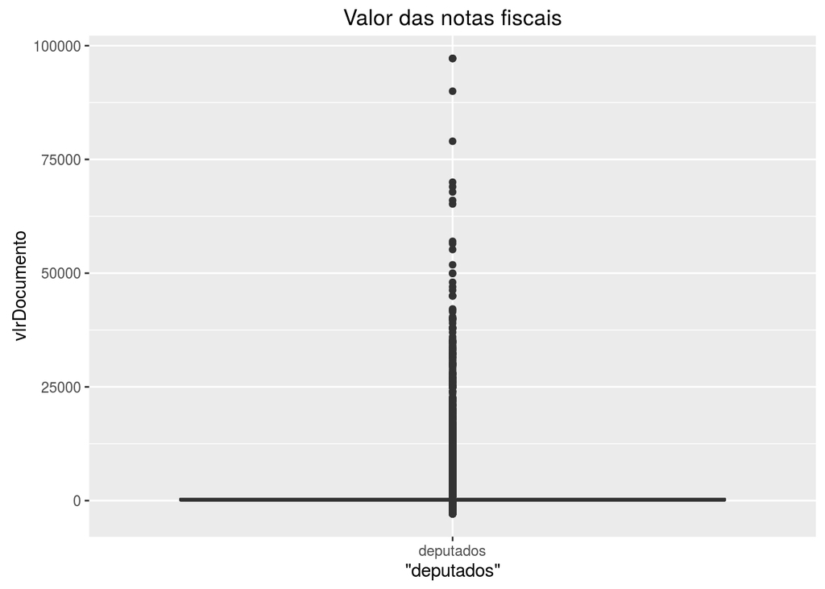

```r
ggplot(dados, aes(y = vlrDocumento, x = "deputados")) +
  geom_boxplot() +
  ggtitle("Valor das notas fiscais")
```

```r
summary(dados$vlrDocumento)
```

```
##     Min.  1st Qu.   Median     Mean  3rd Qu.     Max.
## -2911.00    48.94   141.40   599.10   431.00 97200.00
```

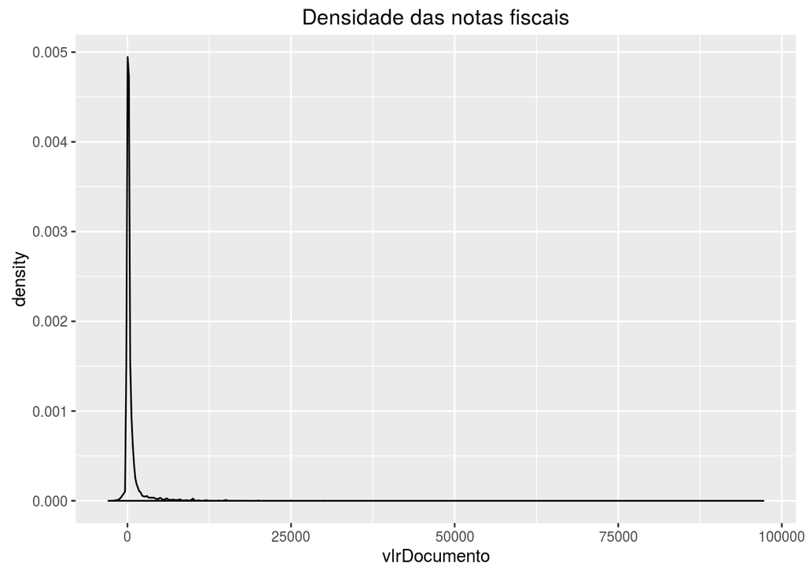

```r
ggplot(dados, aes(x = vlrDocumento)) +
  geom_density() +
  ggtitle("Densidade das notas fiscais")
```

Vemos que os valores estão bem concentrados, sendo 50% dos mesmos entre 48.94 e 431.00, mas os mesmos estão bem enviesados a direita devido ao fato de termos valores muito altos, como vemos no gráfico de densidade. Podemos perceber também algo muito estranho, pois existem valores negativos para o valor da nota fiscal! Vamos verificar se são poucos deputados que tem esses valores e qual a causa desse gasto.

```r
vlrDocumento.negativo <- dados %>%
  filter(vlrDocumento < 0)
```

464 parlamentares têm valor da nota fiscal negativa, logo, aparentemente, não parece ser um erro. Porém, para não restar dúvida, vamos ver qual a descrição dos gastos de valores negativos:

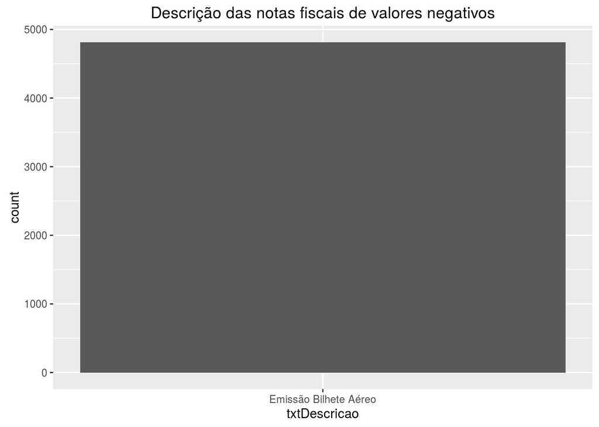

```r
ggplot(vlrDocumento.negativo, aes(x = txtDescricao)) +
  geom_bar() +
  ggtitle("Descrição das notas fiscais de valores negativos")
```

Vemos que em sua totalidade foram emissões de bilhetes aéreos. Talvez de alguma forma isso represente um ressarcimento de passagens aéreas.

Agora, vamos olhar no sentido contrário, os deputados que gastaram mais de 75000 em apenas 1 nota fiscal:

```r
maiores.gastos <- dados %>%
  filter(vlrDocumento > 75000)

maiores.gastos
```

```
##   sgPartido numMes   txtCNPJCPF vlrGlosa     txNomeParlamentar sgUF
## 1       PDT      5 3.386766e+13        0 FÉLIX MENDONÇA JÚNIOR   BA
## 2       PTN      4 3.339851e+12        0  FRANCISCO CHAPADINHA   PA
## 3       PTN      4 3.339851e+12        0  FRANCISCO CHAPADINHA   PA
## 4       PTN      4 3.339851e+12        0  FRANCISCO CHAPADINHA   PA
## 5       PSB      4 1.113099e+13        0      GONZAGA PATRIOTA   PE
##   nuCarteiraParlamentar vlrDocumento nuDeputadoId numSubCota
## 1                   195        90000         2307          5
## 2                    28        97200         2916          5
## 3                    28        97200         2916          5
## 4                    28        97200         2916          5
## 5                   143        79000          137          5
##   txtDescricaoEspecificacao          datEmissao codLegislatura numParcela
## 1                      <NA> 2016-05-25T00:00:00             55          0
## 2                      <NA> 2016-04-04T00:00:00             55          0
```

[output cut: 27 more lines]

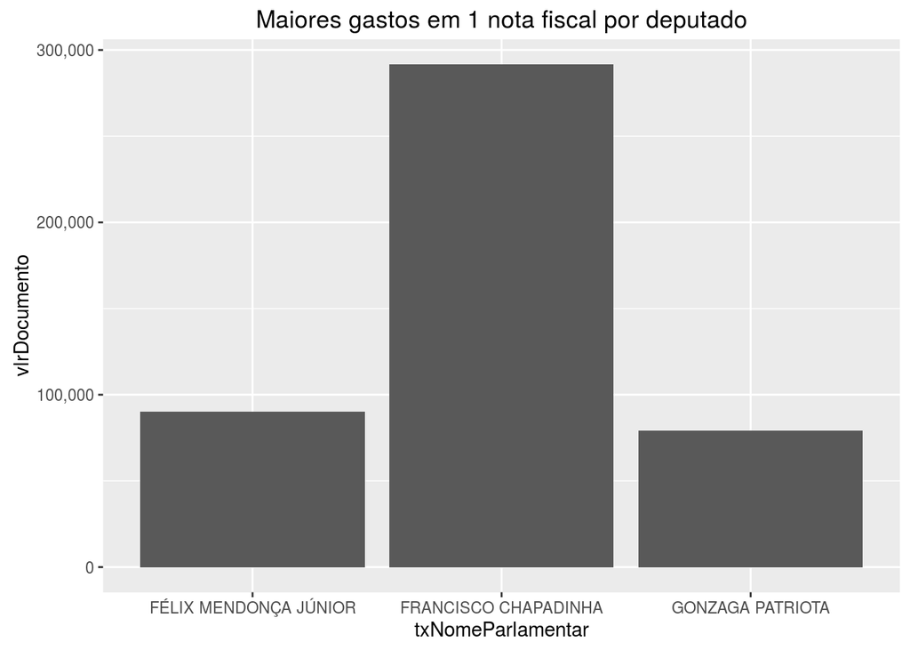

```r
ggplot(maiores.gastos, aes(x = txNomeParlamentar, y = vlrDocumento)) +
  geom_bar(stat = "identity") +
  scale_y_continuous(labels = comma) +
  ggtitle("Maiores gastos em 1 nota fiscal por deputado")
```

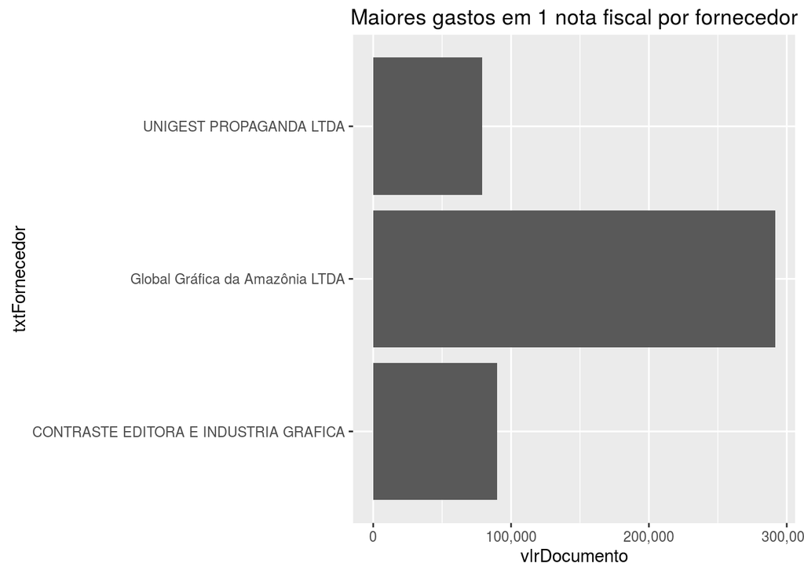

```r
ggplot(maiores.gastos, aes(x = txtFornecedor, y = vlrDocumento)) +
  geom_bar(stat = "identity") +
  scale_y_continuous(labels = comma) +
  ggtitle("Maiores gastos em 1 nota fiscal por fornecedor") +
  coord_flip()
```

Algo muito estranho é ter o deputado FRANCISCO CHAPADINHA que gastou cerca de 300000 reais em apenas um dia na Global Gráfica da Amazônia. O que nos desperta a curiosidade nas seguintes questões:

- Quais são os deputados que mais gastam no Brasil?
- Quais são as os fornecedores que mais enriquecem com os deputados?

Vamos agora ver quais os deputados que mais gastaram no Brasil no ano de 2016:

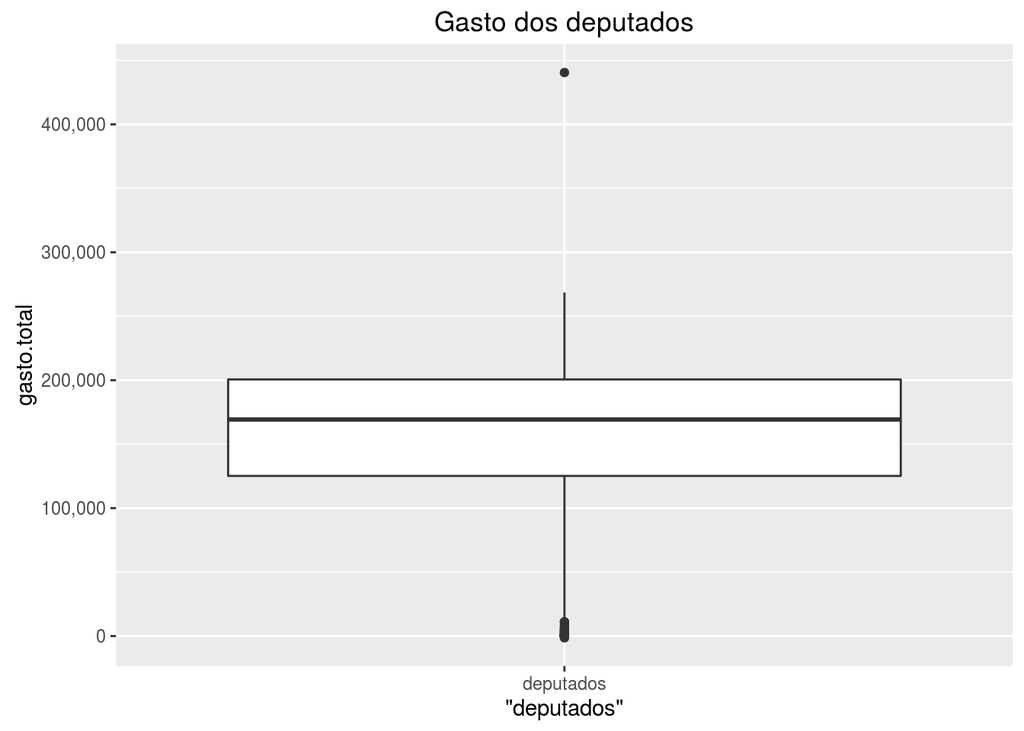

```r
deputados.que.mais.gastam <- dados %>%
  group_by(txNomeParlamentar) %>%
  summarise(gasto.total = sum(vlrDocumento)) %>%
  arrange(desc(gasto.total))

ggplot(deputados.que.mais.gastam, aes(x = "deputados", y = gasto.total)) +
  geom_boxplot() +
  scale_y_continuous(labels = comma) +
  ggtitle("Gasto dos deputados")
```

```r
deputados.que.mais.gastam %>%
  head()
```

```
## Source: local data frame [6 x 2]
##
##      txNomeParlamentar gasto.total
##                 (fctr)       (dbl)
## 1 FRANCISCO CHAPADINHA    440522.9
## 2        BETINHO GOMES    268539.2
## 3        DOMINGOS NETO    267290.0
## 4      GIOVANI CHERINI    266232.2
## 5      HIRAN GONÇALVES    264641.5
## 6     ODORICO MONTEIRO    261916.0
```

Vemos que tem um ponto que mais se destaca e por coincidência é o deputado FRANCISCO CHAPADINHA, onde ele gastou quase R$200000,00 a mais em relação ao 2º que mais gastou.

Vamos agora ver quais fornecedores que mais enriquecem com os deputados:

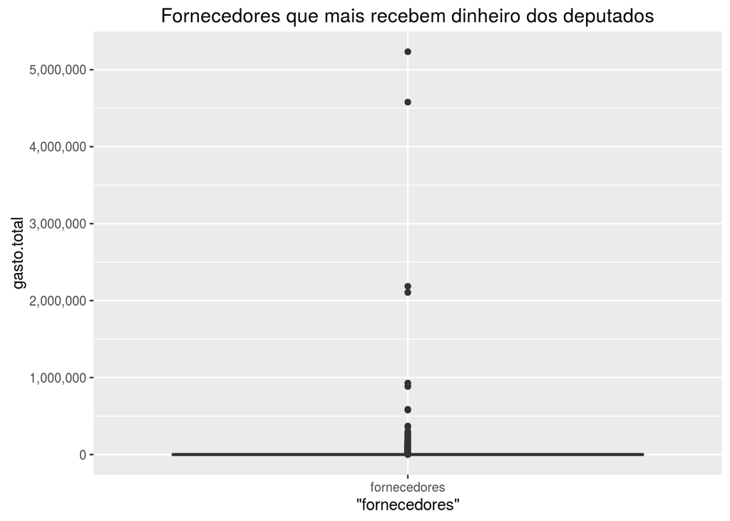

```r
fornecedores.que.mais.ganham <- dados %>%
  group_by(txtFornecedor) %>%
  summarise(gasto.total = sum(vlrDocumento)) %>%
  arrange(desc(gasto.total))

ggplot(fornecedores.que.mais.ganham, aes(x = "fornecedores", y = gasto.total)) +
  geom_boxplot() +
  scale_y_continuous(labels = comma) +
  ggtitle("Fornecedores que mais recebem dinheiro dos deputados")
```

```r
fornecedores.que.mais.ganham %>%
  head(n = 15)
```

```
## Source: local data frame [15 x 2]
##
##                      txtFornecedor gasto.total
##                             (fctr)       (dbl)
## 1                  Cia Aérea - TAM   5234336.0
## 2                  Cia Aérea - GOL   4578923.8
## 3                 Cia Aérea - AZUL   2186230.0
## 4              Cia Aérea - AVIANCA   2106247.0
## 5                CELULAR FUNCIONAL    929036.2
## 6           TELEFÔNICA BRASIL S.A.    888954.3
## 7        DOUGLAS CUNHA DA SILVA ME    885000.0
## 8                            RAMAL    587508.2
## 9           InCine Video Ltda - ME    578280.0
## 10   CORREIOS - SEDEX CONVENCIONAL    370852.7
## 11      CORREIOS - CARTA COMERCIAL    358732.3
## 12               Tam Linhas Aéreas    296179.9
## 13 Global Gráfica da Amazônia LTDA    291600.0
## 14   JOSELY FERNANDA DO NASCIMENTO    275500.0
## 15           Cia Aérea - PASSAREDO    262735.0
```

Vemos que a maior parte dos gastos são com passagens aéreas, telefonia e correios, porém vemos certos fornecedores estranhos como “DOUGLAS CUNHA DA SILVA ME”, “JOSELY FERNANDA DO NASCIMENTO” e “Global Gráfica da Amazônia LTDA”.

##### Resposta (a):

##### O valor das notas fiscais estão bem concentrados, pois 50% dos dados estão entre R$48,94 e R$431,00.

##### Porém existem uma grande quantidade de valores fora desta faixa, variando de -R$2911,00 e R$97200,00.

##### Os gráfico da densidade mostra que os dados são bastante enviesados a direita, logo são bastante assimétricos.

##### Com relação a centralidade dos dados, provavelmente a mediana dos dados represente melhor o conjunto do que a média, tendo em vista a assimetria dos mesmos.

##### (b) há algo surpreendente ou estranho nos dados?

##### Resposta (b):

##### Como vimos anteriormente, os dados do valor da nota fiscal são bem estranhos, pois é difícil imaginar que existam valores negativos, porém quando investigamos mais a fundo, pudemos perceber que todos os dados se tratam de emissão de bilhetes aéreos.

##### (c) como você sugere que um analista de dados lide com a parte surpreendente/estranha?

##### Resposta (c):

##### Para este caso específico, como concluímos que os valores negativos são provenientes de ressarcimentos das companhias aéreas, nas análises subsequentes que utilizam o valor da nota fiscal, seria interessante o analista de dados remover esses valores negativos, para que o gasto dos políticos não fique negativo, dando a entender que ele “doa dinheiro para o estado”. Porém não podemos generalizar, pois cada caso é um caso.

Vamos explorar um pouco mais os dados para conhecê-los melhor.

Vamos agora ver quais os partidos com mais deputados:

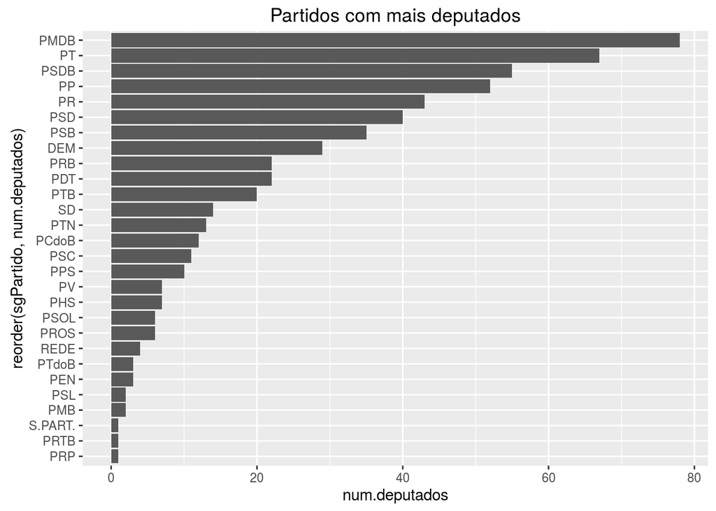

```r
deputados.por.partido <- dados %>%
  filter(!is.na(sgPartido)) %>%
  group_by(sgPartido, ideCadastro) %>%
  distinct() %>%
  group_by(sgPartido) %>%
  summarise(
    num.deputados = n()
  )

ggplot(deputados.por.partido, aes(x = reorder(sgPartido, num.deputados), y = num.deputados)) +
  geom_bar(stat = "identity") +
  coord_flip() +
  ggtitle("Partidos com mais deputados")
```

Vemos que o partido com maior número de deputados é o PMDB, seguido pelo PT e PSDB.

Veremos agora os partidos que tem maior gasto:

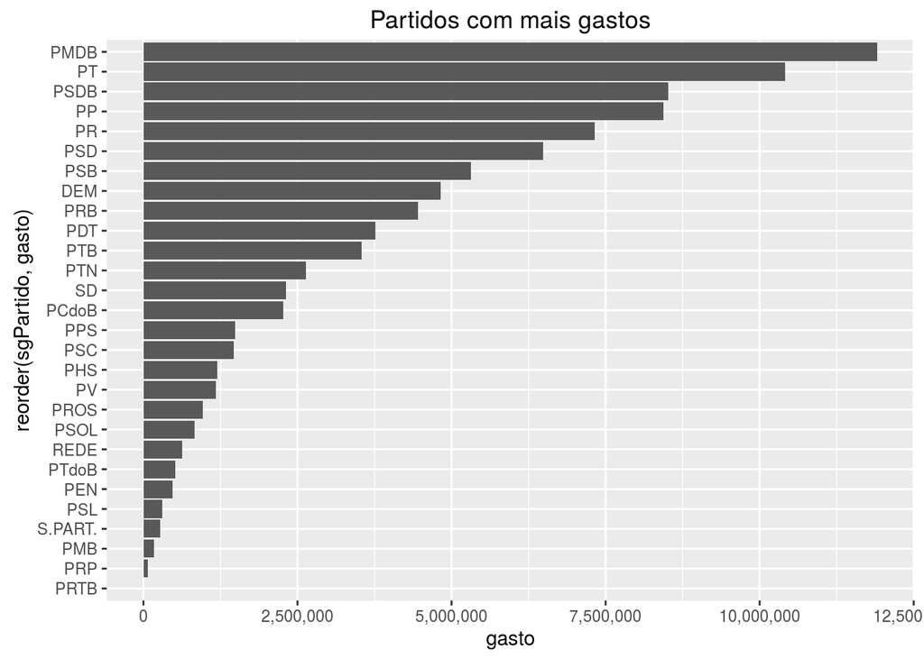

```r
dados.positivos <- dados %>%
  filter(vlrDocumento >= 0)

gasto.por.partido <- dados.positivos %>%
  filter(!is.na(sgPartido)) %>%
  group_by(sgPartido) %>%
  summarise(
    gasto = sum(vlrDocumento)
  )

ggplot(gasto.por.partido, aes(x = reorder(sgPartido, gasto), y = gasto)) +
  geom_bar(stat = "identity") +
  coord_flip() +
  scale_y_continuous(label = comma) +
  ggtitle("Partidos com mais gastos")
```

Vemos que aparentemente, quanto maior a quantidade de deputados, maior o gasto do partido, pois segue quase a mesma ordem, mas vamos verificar se isso é realmente um padrão:

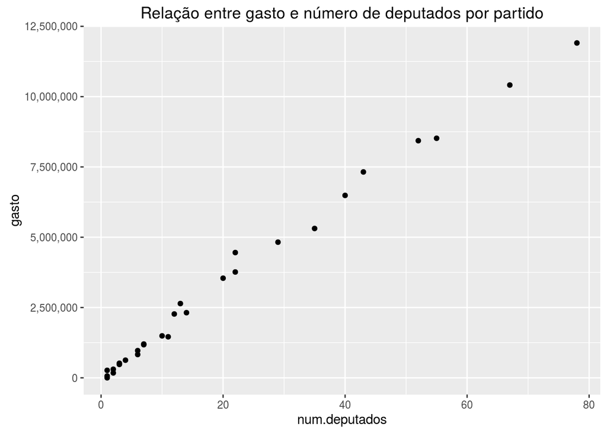

```r
partidos.numDeputados.gasto <- full_join(deputados.por.partido, gasto.por.partido, by = "sgPartido")

ggplot(partidos.numDeputados.gasto, aes(x = num.deputados, y = gasto)) +
  geom_point() +
  scale_y_continuous(labels = comma) +
  ggtitle("Relação entre gasto e número de deputados por partido")
```

Como podemos perceber, realmente o gasto dos partidos é proporcional ao número de deputados do partido.

Vamos ver agora se existe algum mês deste ano que houve maior gasto, ou todos se comportam de forma parecida:

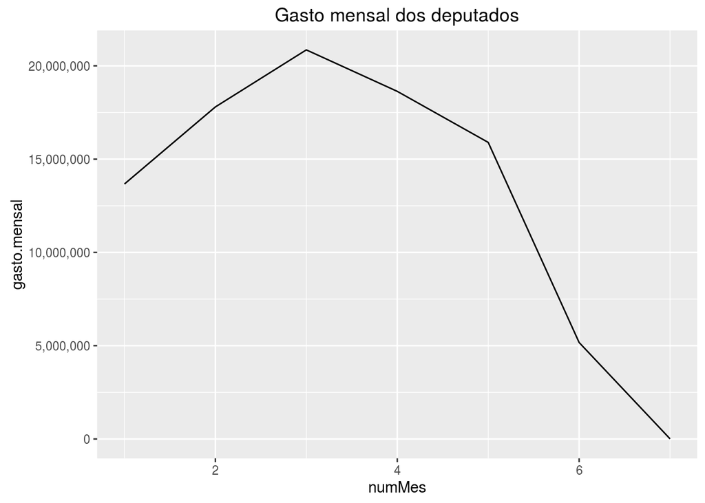

```r
gastos.mensais <- dados.positivos %>%
  group_by(numMes) %>%
  summarise(gasto.mensal = sum(vlrDocumento))

ggplot(gastos.mensais, aes(x = numMes, y = gasto.mensal)) +
  geom_line() +
  scale_y_continuous(labels = comma) +
  ggtitle("Gasto mensal dos deputados")
```

O mês de julho teve poucas observações (apenas 90 observações), com isso, o valor do gasto mensal de julho é bem menor que os demais. Os demais dados parecem quase uma distribuição normal, porém como não temos dados do ano todo, não podemos afirmar nada.

## Parte 2

##### a. Em que tipo de despesas nossos parlamentares gastam mais recursos de sua cota?

Vamos agora ver quais são as maiores causas de gasto dos deputados:

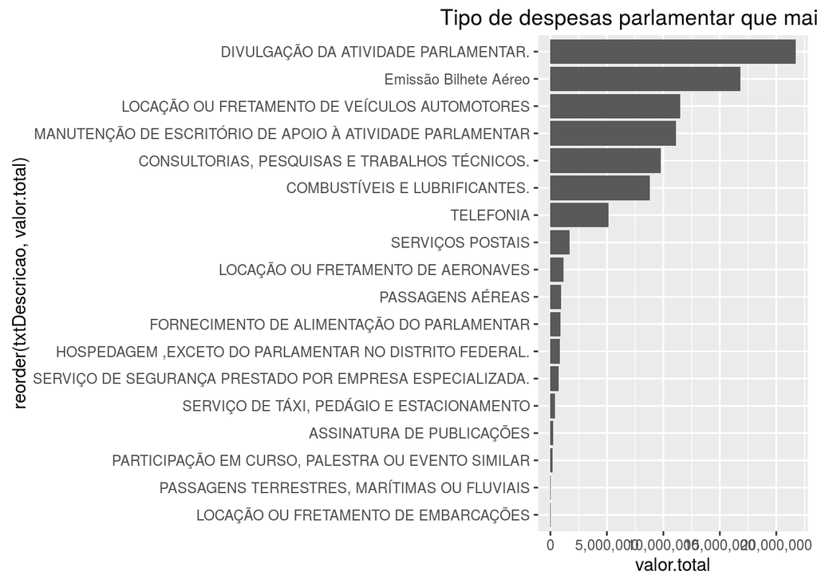

```r
causa.dos.gastos <- dados.positivos %>%
  group_by(txtDescricao) %>%
  summarise(valor.total = sum(vlrDocumento))

ggplot(causa.dos.gastos, aes(x = reorder(txtDescricao, valor.total), y = valor.total)) +
  geom_bar(stat = "identity") +
  coord_flip() +
  scale_y_continuous(label = comma) +
  ggtitle("Tipo de despesas parlamentar que mais gastam")
```

##### Resposta (a):

##### Vemos que as despesas que gastam mais recursos são as divulgações das atividades parlamentares, seguido da emissão de bilhetes aéreos e locação de veículos.

##### b. Quais tipos de despesas têm despesas que mais variam, que têm valores mais desiguais?

Vamos agora verificar quais as despesas que mais variam:

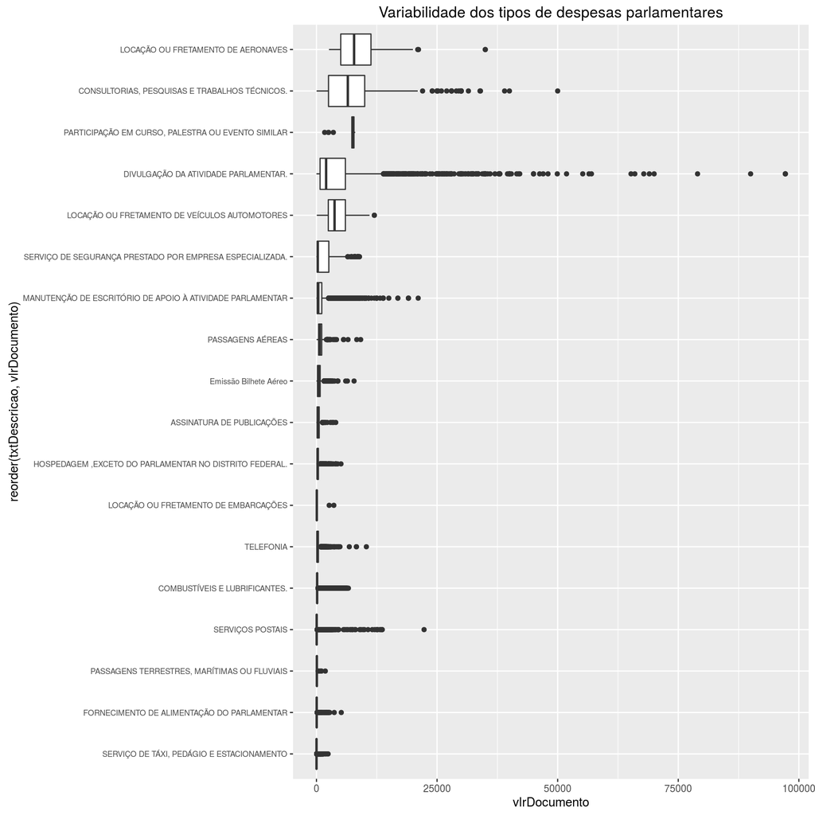

```r
ggplot(dados.positivos, aes(x = reorder(txtDescricao, vlrDocumento), y = vlrDocumento, group = txtDescricao)) +
  geom_boxplot() +
  coord_flip() +
  ggtitle("Variabilidade dos tipos de despesas parlamentares") +
  theme(axis.text.y = element_text(size=7))
```

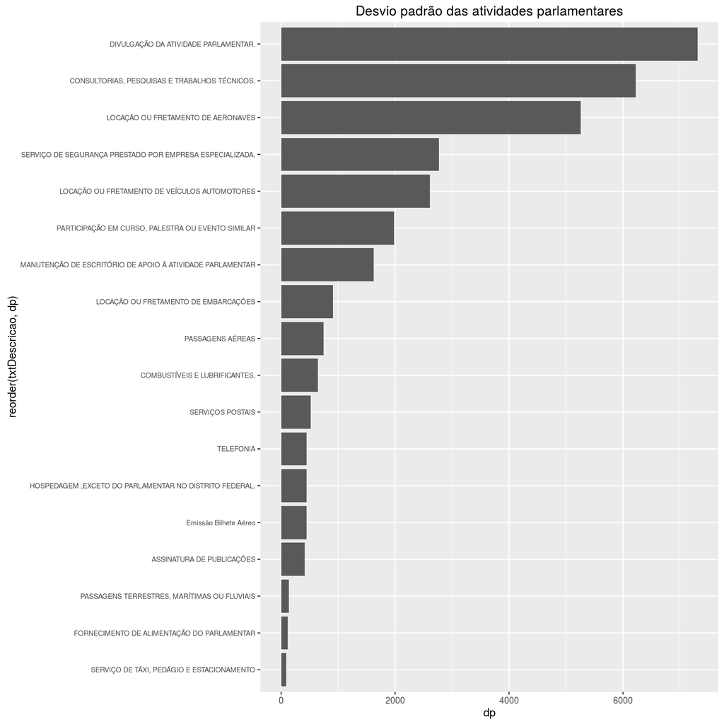

```r
dp.descricoes <- dados.positivos %>%
  group_by(txtDescricao) %>%
  summarise(
    dp = sd(vlrDocumento)
    )

ggplot(dp.descricoes, aes(x = reorder(txtDescricao, dp), y = dp)) +
  geom_bar(stat = "identity") +
  coord_flip() +
  ggtitle("Desvio padrão das atividades parlamentares") +
  theme(axis.text.y = element_text(size=7))
```

##### Resposta (b):

##### As despesas que mais variam são as divulgações de atividades parlamentares, seguido de consultorias, pesquisas e trabalhos técnicos.